# March 30 2023 glycogen test

in-cycle

In-cycle sampling with glycogen test on Thursday, March 30 3023

This week I tested the glycogen extraction and measurement with some in-cycle samples. Samples for glycogen analysis were collected during the anaerobic and anoxic phases of the reactor cycle. A rough draft of the protocol used for the glycogen extraction and measurement can be found [here](https://mckennafarmer.notion.site/Glycogen-testing-d78b170286494ce695053984b7ba05c2).

## Notebook set up

```r
options(scipen = 0, digits = 2)

# functions
source("./scripts/cycle_parsing.R")
source("./scripts/pull_solids.R")
source("./scripts/plotting.R")

# packages
library(MetBrewer)
library(ggplot2)
library(readxl)
library(lubridate)
library(reshape2)
library(dplyr)

# misc.
base_path <- "C:/Users/mckyf/Northwestern University/Wells Research Group - CANDO+P Reactor/04 Performance data/"
# data
file_path <- "In-cycle sampling"
excel_cycle <- "230330_gly_cycletest.xlsx"
excel_solids <- "daily_weekly_measurements.xlsx"
choose_date <- "2023-03-30"

df <- read_excel(file.path(base_path, file_path, excel_cycle))
solids <- get_recent_tss(file.path(base_path, excel_solids), choose_date)


# light parsing
df <- df %>%
  mutate(hour = time_length(interval(min(time), time), "hour")) %>%
  select(-c(date, time)) %>%
  filter(phase %in% c("ana", "anx")) %>%
  melt(id = c("hour", "phase"))
```

# In-cycle plots

## Nutrient profile

Here is the phosphorus and nitrite profile over the sampling period. Note that the nitrate concentration was minimal so was excluded from this plot.

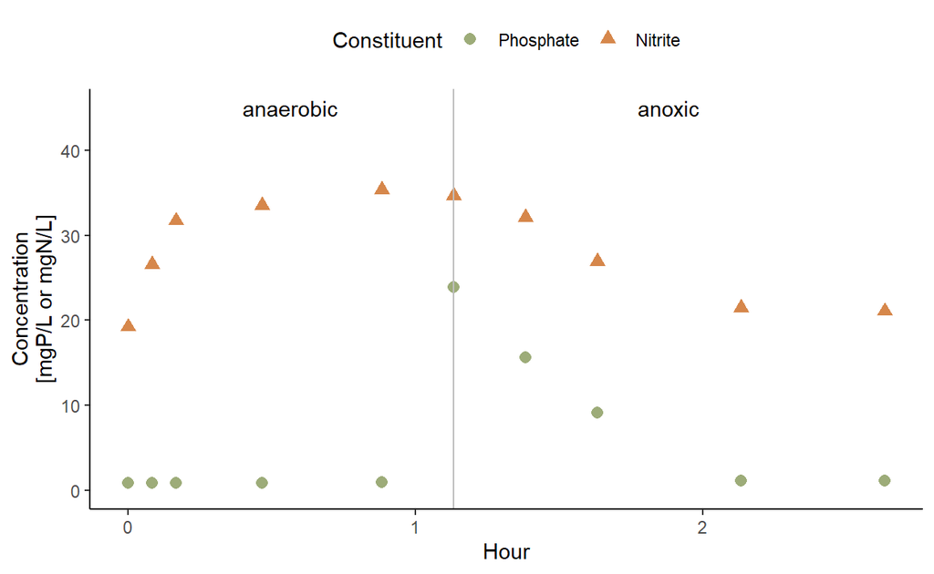

```r
## plotting params - phase labels and lines
ylim_custom <- round(max(df$value, na.rm = TRUE) + 10, 0)

# dynamic phase lines
phase_times <- df %>% group_by(phase) %>% summarise(t0 = min(hour))

phase_lines <- list(
  geom_vline(xintercept = filter(phase_times, phase == "anx")$t0, color="grey"))


phase_labs <- list(
  annotate("text", x = mean(phase_times$t0[1:2]), y = ylim_custom, label = "anaerobic"),
  annotate("text", x = mean(c(phase_times$t0[2], max(df$hour))), y = ylim_custom, label = "anoxic")
)


# pull colors and shapes
plot_list <- c("phosphate", "nitrite") # this has to be in order

plot_palette <- palette_df %>% filter(vars %in% plot_list)

custom_color <- scale_color_manual(name="Constituent",
                                   values=plot_palette$colors,
                                   labels=plot_palette$labels)

custom_shape <- scale_shape_manual(name="Constituent",
                                   values=plot_palette$shapes,
                                   labels=plot_palette$labels)


df %>% filter(variable %in% plot_list) %>%
  ggplot(data=.,aes(x=hour, y=value, color=variable, shape=variable)) +
  geom_point(size=2.5, alpha = 0.9) +
  custom_color +
  custom_shape +
  phase_lines +
  theme_defaults +
  phase_labs +
  labs(y="Concentration\n[mgP/L or mgN/L]", x="Hour") +
  ylim(0, ylim_custom)
```

## Carbon profile

This is the COD profile over the same time period. Glucose was not added to this in=cycle test. Note that the glycogen concentration is reported as **mg glucose as COD/g biomass**. This profile does not follow the expected glycogen profile of PAO and GAO, where glycogen would be depleted in the anaerobic phase and replenished in the anoxic phase. I am going to try the measurement again this coming week with a few adjustments - the protocol I used this week can be found [here](https://mckennafarmer.notion.site/Glycogen-testing-d78b170286494ce695053984b7ba05c2).

Adjustments for Monday, April 3rd:

- Add biomass into the digestion tube to produce a final digestion ratio of 1 mg biomass per 1 mL 0.9 M HCl. My ratio ended up being closer to 0.35 mg biomass per 1 mL 0.9 M HCl, so glycogen may not have been hydrolysed completely in all samples.
- Take biomass samples from the aerobic phase. I only took samples from the anaerobic and anoxic phases to test the method with fewer samples, so I will add aerobic timepoints to better understand the complete glycogen profile.

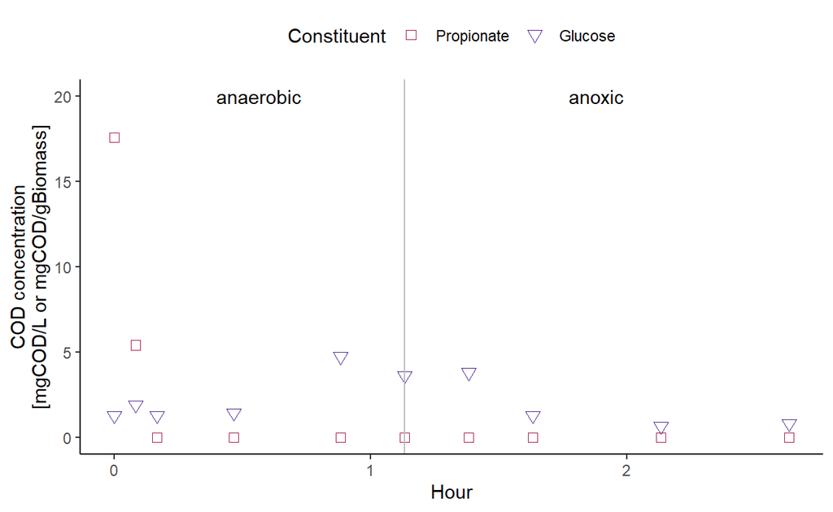

```r
df_gly <- df %>% filter(variable == "glucose")

# calculate mg glycogen/g biomass
df_gly$value <- df_gly$value * 3 / (solids$TSS * 0.015 / 0.010)

df_carbon <- rbind(df_gly, subset(df, variable == "propionate"))

ylim_custom <- 20 # have to manually mess with this with the dual y axis

phase_labs <- list(
  annotate("text", x = mean(phase_times$t0[1:2]), y = ylim_custom, label = "anaerobic"),
  annotate("text", x = mean(c(phase_times$t0[2], max(df$hour))), y = ylim_custom, label = "anoxic")
)

plot_list <- c("propionate", "glucose")

plot_palette <- palette_df %>% filter(vars %in% plot_list)

custom_color <- scale_color_manual(name="Constituent",
                                   values=plot_palette$colors,
                                   labels=plot_palette$labels)

custom_shape <- scale_shape_manual(name="Constituent",
                                   values=plot_palette$shapes,
                                   labels=plot_palette$labels)


df_carbon %>% filter(variable %in% plot_list) %>%
    ggplot(data=., aes(x=hour, y=value, color = variable, shape = variable)) +
    geom_point(size=2.5) +
    phase_lines +
    phase_labs +
    custom_color +
    custom_shape +
    theme_defaults +
    labs(y="COD concentration\n[mgCOD/L or mgCOD/gBiomass]", x="Hour")
```

# Maximum rate calculations

Maximum removal rates are calculated from the linear parts of the nutrient or carbon profile. Rates are normalized to solids measurements.

## P release rate

Based on the in-cycle plot, I will use the first 3 timepoints for this calculation.

```r
n_points <- 3

ana_df <- df %>%
  filter(hour <= phase_times$t0[2]) %>%
  filter(variable %in% c("phosphate", "propionate"))

ana_phos_df <- ana_df %>%
  filter(variable == "phosphate") %>%
  slice(1:n_points)

lm_ana_phos <- lm(value ~ hour, data = ana_phos_df)

ana_phos_rate <- abs(unname(coef(lm_ana_phos)["hour"]) / filter(solids, sample == "ml")$TSS)
```

## Denitrification rate & anoxic P uptake

Based on the in-cycle plot, I will use the first 4 timepoints for this calculation.

```r
n_points <- 4

# get anoxic data
anx_df <- df %>%
  filter(hour >= phase_times$t0[2]) %>%
  filter(variable %in% c("nitrite", "phosphate"))


anx_nitrite_df <- anx_df %>% filter(variable == "nitrite") %>%
  slice(1:n_points)
anx_phos_df <- anx_df %>% filter(variable == "phosphate") %>%
  slice(1:n_points)

lm_anx_nitrite<- lm(value ~ hour, data = anx_nitrite_df)
lm_anx_phos <- lm(value ~ hour, data = anx_phos_df)

# rates normalized to biomass
anx_denit_rate <- abs(unname(coef(lm_anx_nitrite)["hour"]) / filter(solids, sample == "ml")$TSS)
anx_phos_rate <- abs(unname(coef(lm_anx_phos)["hour"]) / filter(solids, sample == "ml")$TSS)
```

```r
rates_df <- tibble(rates = c("phos_rel", "phos_up", "nit_denit"),
                   values = c(ana_phos_rate, anx_phos_rate, anx_denit_rate),
                   date = choose_date)

saveRDS(rates_df, file = paste0("./data/rates-", choose_date, ".RDS"))
```

## Last updated on

```r
print(today())
```

```
[1] "2023-04-02"
```